# AI Use and Verification

A concise record of AI-supported work on this project.

Author

Sami Schofield, Claire Uryan, Annmarie Scott

This page is a work log, not a second report. Short bullets are welcome. It is separate from the final case study and does not count toward the 750 to 1,000 word range.

## Starting point

**AI system and date:** Gemini November 4

**Before using AI for the required extension, briefly state your question, course-based core model, baseline result, and the specific limitation or opportunity you wanted to address.**

Question: How is mental health associated with age, gender, county, profession, daily usage hours, primary platform, notification frequency and sleep disruption?

Model:

$$\begin{aligned}
y_i &= \beta_0 + \beta_1 \text{age}_i + \beta_2 \text{gender}_i + \beta_3 \text{country}_i + \beta_4 \text{profession}_i \\
&\quad + \beta_5 \text{usage}_i + \beta_6 \text{platform}_i + \beta_7 \text{notifications}_i + \beta_8 \text{sleep\_disruption}_i + \epsilon_i \\
\epsilon &\sim \mathcal{N}(0, \sigma^2)
\end{aligned}$$

```r
library(tidyverse)
library(car)
social_media <- read.csv("social_media_user_behavior.csv") %>%
select(self_reported_mental_health_score, sleep_disruption, notification_frequency, daily_usage_hours, primary_platform, profession, country, gender, age) %>%
rename(mental_health = self_reported_mental_health_score)
fitted_social <- lm(mental_health ~ ., data = social_media)
summary(fitted_social)
```

```
Call:
lm(formula = mental_health ~ ., data = social_media)

Residuals:
    Min      1Q  Median      3Q     Max
-5.2030 -1.2176  0.0306  1.2124  4.1481

Coefficients:
                                      Estimate Std. Error t value Pr(>|t|)
(Intercept)                           6.029855   0.284262  21.212   <2e-16 ***
sleep_disruptionModerate impact       0.158648   0.104152   1.523   0.1279
sleep_disruptionNo impact             0.099938   0.098524   1.014   0.3105
sleep_disruptionSevere impact         0.045659   0.136165   0.335   0.7374
notification_frequencyDo Not Disturb  0.032542   0.112289   0.290   0.7720
notification_frequencyOff            -0.020231   0.145487  -0.139   0.8894
notification_frequencySelected       -0.034082   0.096690  -0.352   0.7245
daily_usage_hours                     0.020028   0.021303   0.940   0.3473
primary_platformInstagram            -0.171327   0.137983  -1.242   0.2145
primary_platformLinkedIn             -0.168197   0.199283  -0.844   0.3988
primary_platformPinterest            -0.059153   0.218622  -0.271   0.7867
primary_platformSnapchat             -0.439325   0.176821  -2.485   0.0131 *
primary_platformTikTok               -0.257235   0.139331  -1.846   0.0650 .
primary_platformTwitter/X            -0.150619   0.146466  -1.028   0.3039
primary_platformYouTube              -0.176535   0.154624  -1.142   0.2537
professionDoctor                      0.151621   0.189555   0.800   0.4239
professionEngineer                    0.127574   0.180737   0.706   0.4804
professionEntrepreneur               -0.022213   0.184803  -0.120   0.9043
professionFreelancer                  0.153858   0.187767   0.819   0.4127
professionMarketer                    0.323881   0.183046   1.769   0.0770 .
professionOther                       0.135544   0.183240   0.740   0.4596
professionResearcher                  0.322251   0.183812   1.753   0.0797 .
professionStudent                     0.322226   0.186153   1.731   0.0836 .
professionTeacher                     0.233421   0.182561   1.279   0.2012
countryBrazil                         0.007032   0.236253   0.030   0.9763
countryCanada                        -0.294396   0.201705  -1.460   0.1446
countryGermany                       -0.214793   0.209725  -1.024   0.3059
countryIndia                         -0.154483   0.176416  -0.876   0.3813
countryNigeria                       -0.007357   0.231081  -0.032   0.9746
countryPakistan                       0.006994   0.173416   0.040   0.9678
countryUAE                           -0.161551   0.196657  -0.821   0.4115
countryUK                            -0.097504   0.196859  -0.495   0.6204
countryUSA                           -0.079541   0.177237  -0.449   0.6536
genderMale                            0.091099   0.081199   1.122   0.2620
genderNon-binary                     -0.091354   0.224490  -0.407   0.6841
genderPrefer not to say               0.284190   0.281613   1.009   0.3130
age                                   0.002589   0.005185   0.499   0.6177
---
Signif. codes:  0 '***' 0.001 '**' 0.01 '*' 0.05 '.' 0.1 ' ' 1

Residual standard error: 1.753 on 1963 degrees of freedom
Multiple R-squared:  0.01377,   Adjusted R-squared:  -0.004315
F-statistic: 0.7614 on 36 and 1963 DF,  p-value: 0.846
```

Limitation: Our R^2 is very small and show that these predictors don’t explain for a lot of the variation in mental health.

Opportunity: There may be other data that is linked more directly with mental health and social media or mental health and other predictors that represent it well.

## Substantive prompts

Paste the exact prompts that shaped the extension. Include the customized extension-selection prompt from the checkpoint and any important implementation follow-ups. Delete unused prompt blocks.

> I am creating a regression case study in R and Quarto.

> Question: How is mental health associated with age, gender, county, profession, daily usage hours, primary platform, notification frequency and sleep disruption?

> Model:

> $$\begin{aligned}
> y_i &= \beta_0 + \beta_1 \text{age}_i + \beta_2 \text{gender}_i + \beta_3 \text{country}_i + \beta_4 \text{profession}_i \\
> &\quad + \beta_5 \text{usage}_i + \beta_6 \text{platform}_i + \beta_7 \text{notifications}_i + \beta_8 \text{sleep\_disruption}_i + \epsilon_i \\
> \epsilon &\sim \mathcal{N}(0, \sigma^2)
> \end{aligned}$$

> {r} library(tidyverse) library(car) social_media <- read.csv(“social_media_user_behavior.csv”) %>% select(self_reported_mental_health_score, sleep_disruption, notification_frequency, daily_usage_hours, primary_platform, profession, country, gender, age) %>% rename(mental_health = self_reported_mental_health_score) fitted_social <- lm(mental_health ~ ., data = social_media) summary(fitted_social)

> Limitation: Our R^2 is very small and show that these predictors don’t explain for a lot of the variation in mental health.

> Opportunity: There may be other data that is linked more directly with mental health and social media or mental health and other predictors that represent it well. Suggest three feasible extensions that keep the core analysis connected to regression methods taught in my class. One option may be a model not taught in class used as a comparator. For each, explain how it strengthens the same research question, how its result would enter the final case study, the implementation steps, and two ways I could verify it. Do not choose for me.

## My decisions

- **Accepted:** Relax the linearity rule for some of our predictors, mainly the continuous ones like age and daily usage by using smooth spline functions. ** Dr White recomended a “cumulative link” model extension for our case specifically where our response variable is measured on a Likert scale.
- **Changed:** We changed the linearity rule for our continuous predictors in order to be splines. We will further look into AI based on Dr. White’s recommendation of a cumulative link model.
- **Rejected or corrected:** AI suggested a forest method but it was beyond our understanding and knowledge.

**Connection to the final case study:** Adding a spline will effect our final model and affect every step along the way but we ultimately decided to use splines to help with our continuous predictors. We will justify a spline model in our final page.

## Independent verification

1. **Check and result:**

   ```r
   influence_data <- social_media %>% mutate( row = row_number(), leverage = hatvalues(fitted_social), std_resid = rstandard(fitted_social), cooks_d = cooks.distance(fitted_social))

   influence_data %>% slice_max(cooks_d, n = 5) %>% select(row, cooks_d)
   ```

   ```
      row     cooks_d
   1 1842 0.006467608
   2  684 0.006008242
   3 1950 0.005863640
   4 1793 0.005686604
   5 1606 0.005537725
   ```

   ```r
   influence_data %>% slice_max(leverage, n = 3) %>% select(row, leverage)
   ```

   ```
      row   leverage
   1  194 0.04619280
   2  684 0.04550201
   3 1668 0.04520841
   ```

   ```r
   influence_data %>% slice_max(abs(std_resid), n = 3) %>% select(row, std_resid)
   ```

   ```
      row std_resid
   1   11 -2.987841
   2 1950 -2.985837
   3 1250 -2.881560
   ```

2. **Check and result:**

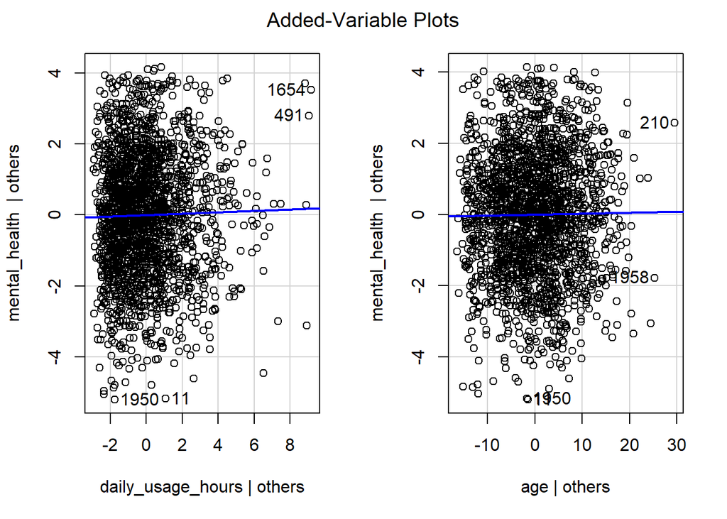

   ```r
   avPlots(fitted_social, terms = ~ mental_health + daily_usage_hours + age)
   ```

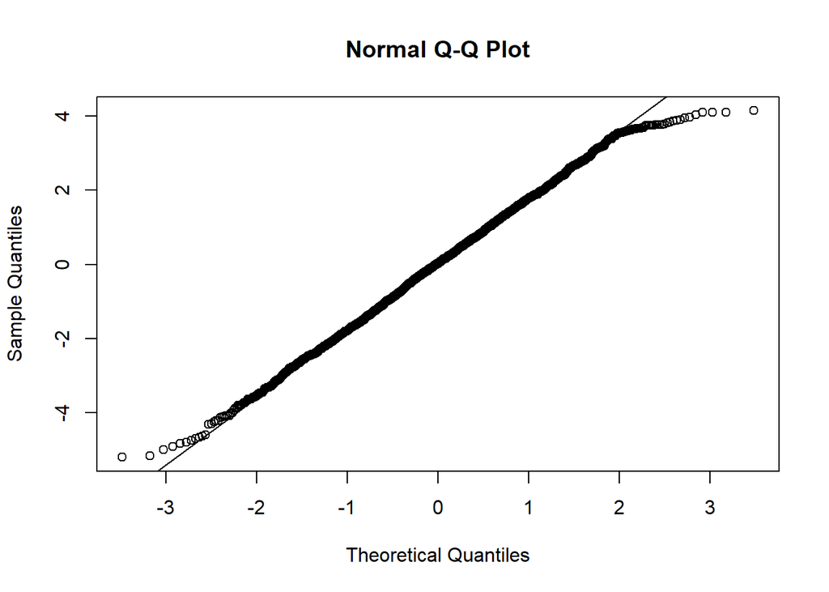

   ```r
   qqnorm(resid(fitted_social)); qqline(resid(fitted_social))
   ```

   ```r
   shapiro.test(resid(fitted_social))
   ```

   ```
       Shapiro-Wilk normality test

   data:  resid(fitted_social)
   W = 0.99681, p-value = 0.000356
   ```

**NOTE: we did not understand what “verification” meant for this assignment, so we ran LINE assumptions on our data without running any verifications on what Gemini recommended with adding splines. We talked to Dr White and he said this was fine to submit as is as long as we include this note.

Link or cite verification sources where appropriate. A second AI response does not count as independent verification.

## Remaining limitation

Our data has a lot of categorical data that cannot always be accounted for in the different plots and models.

## Other AI use, if any

We used ChatGPT to publish the repository for GitHub

Back to top